# Week 17: Model-evaluation quiz [answers]

A total of 59 students completed [this quiz](https://ntupsychology.eu.qualtrics.com/jfe/form/SV_dmtBg1o0LfbVfFk) (status: 2021-02-26 08:30:10). The correct answers are highlighted in green in the bar plots below. If you don’t understand why an answer is correct, or why an answer isn’t correct, please ask on Teams.

## Part 1 (1): assumptions and statistical modelling

### Which acronym is helpful to remember the 4 model assumptions?

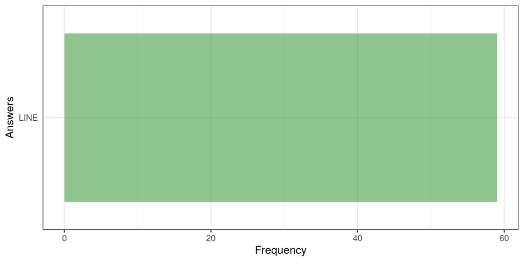

### What might happen if model assumptions are not met?

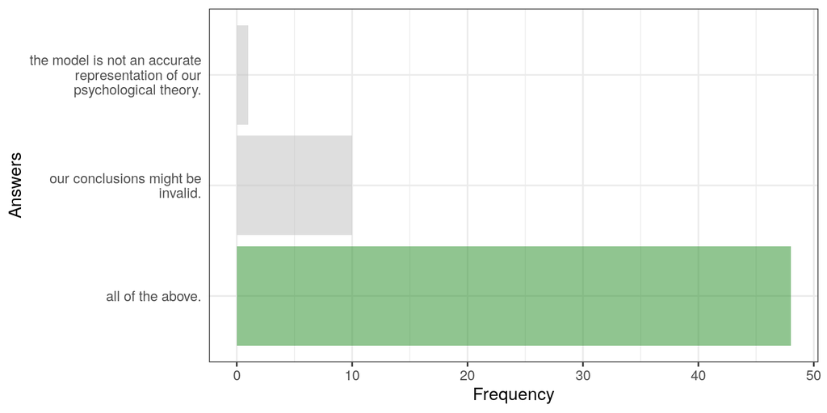

### Is it true that t-tests, ANOVAs and linear regressions are all parametric models?

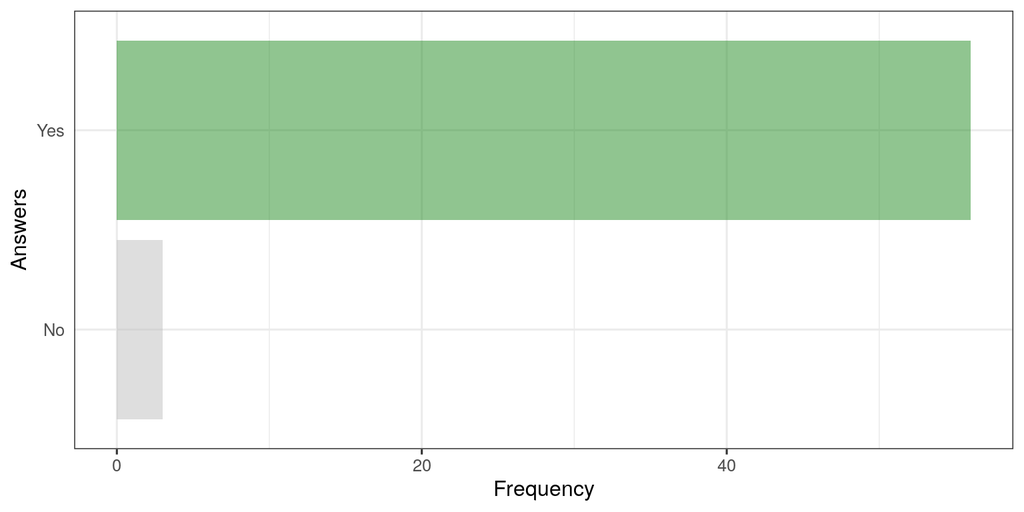

### You have fitted linear regression models in previous workshops. What’s new when we run a t-test or an ANOVA as linear model using lm?

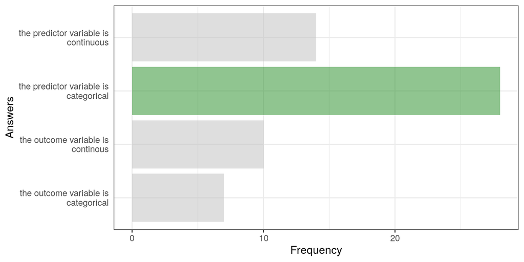

Ooops! Okay granted, this isn’t simple. So far you have learnt linear models with continuous outcome variables (we will cover linear models with non-continous outcome variables next year). ANOVAs and *t*-test have categorical predictor variables which you called groups or conditions. Those are categories (= categorical). In the lecture (and in the workshop week 18) I demoned how to fit linear models with categorical predictors akin to *t*-tests and ANOVAs.

### Why would we use an linear model instead of running a t-test or an ANOVA?

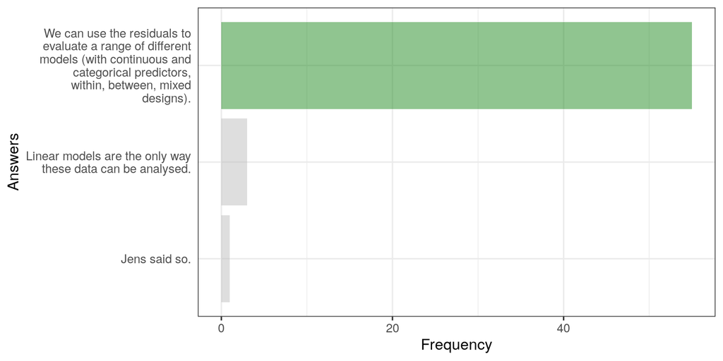

## Part 1 (2): residuals and normality

### Which of the following is *not* a correct paraphrase of residuals?

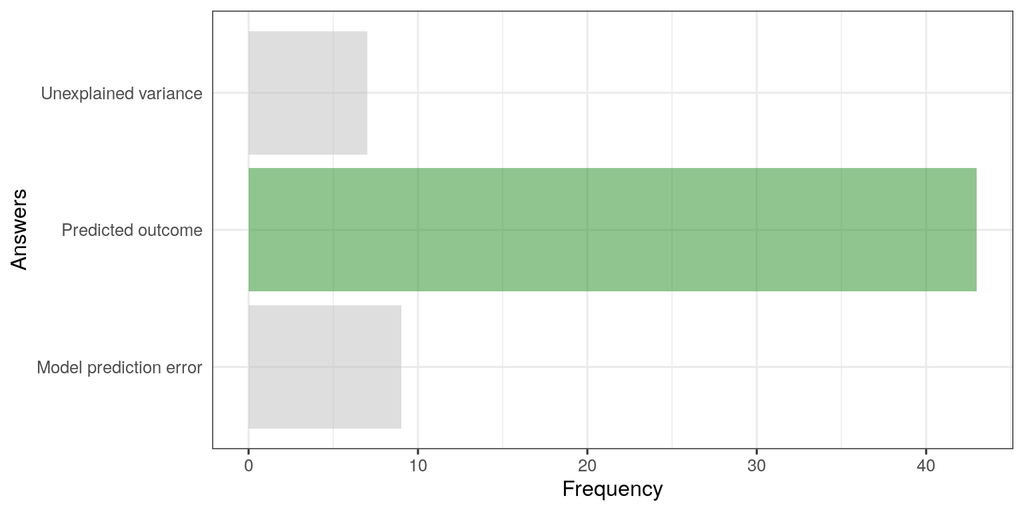

### Which statement is correct for a good model (generally speaking)?

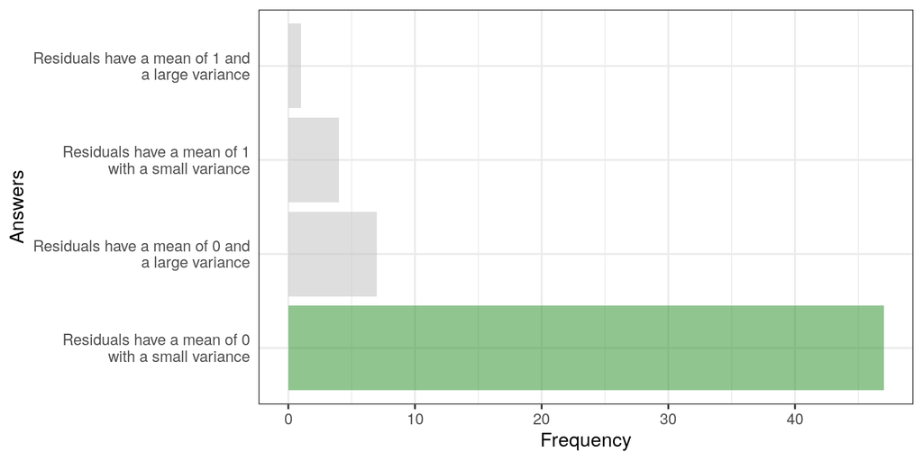

### A positively skewed distribution has a …

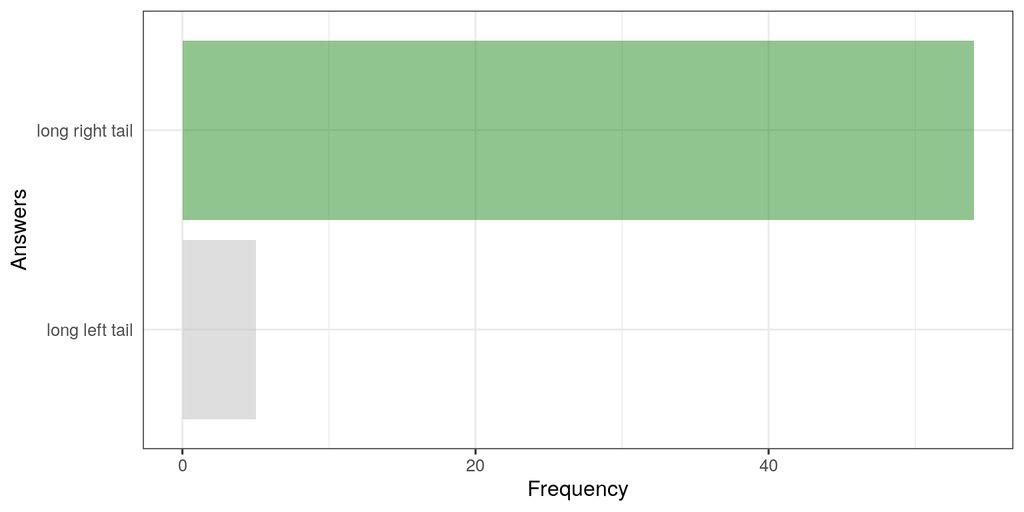

### A skew of 3.5 indicates

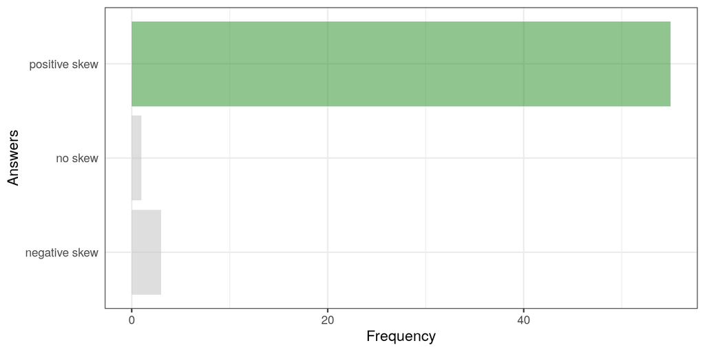

### Which of the following transformations is routinely used in the literature to correct for positive skew, especially for rts?

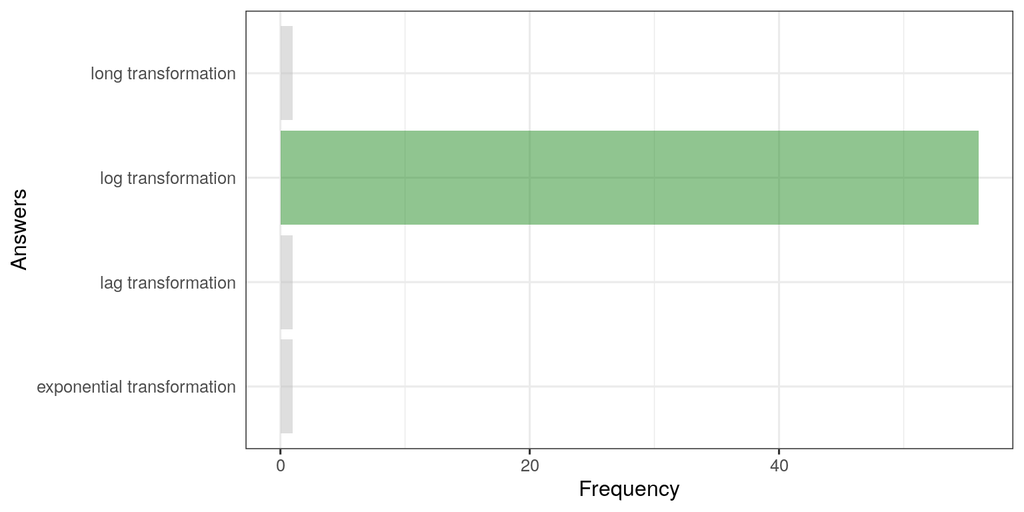

### A random variable x with a kurtosis of 3 is…

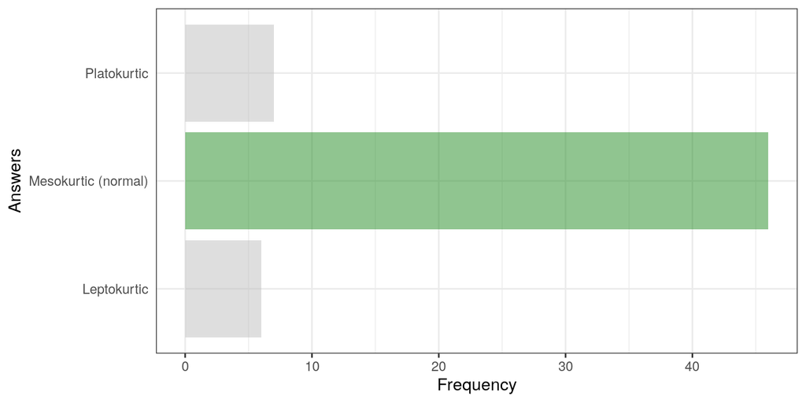

## Part 2: independence of residuals

### Independence of residuals means that there should be (or little) ….

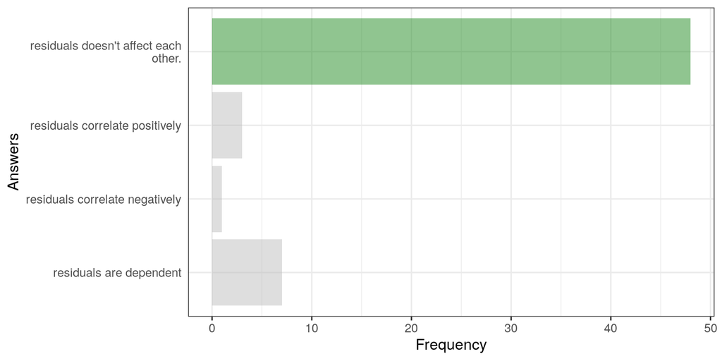

### Residuals should be distributed around an imaginary horizontal line …

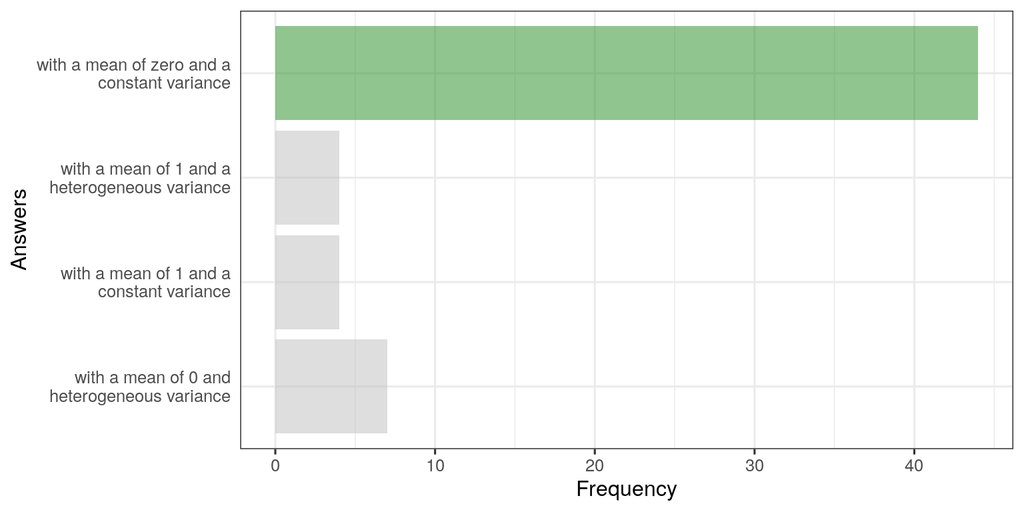

### Two groups meet the equality / homogeneity of variance assumption when:

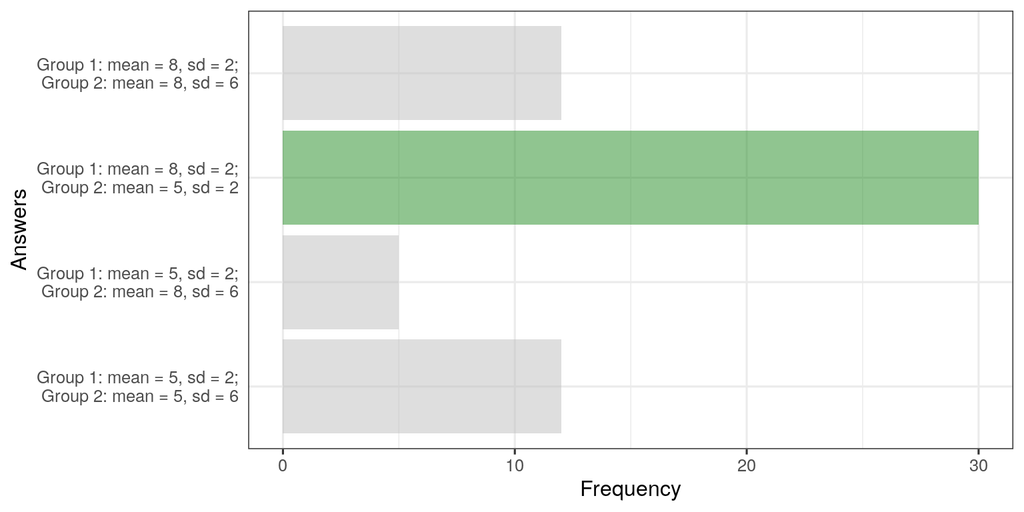

### Two groups may have unequal variances if one group is more diverse so for example when comparing:

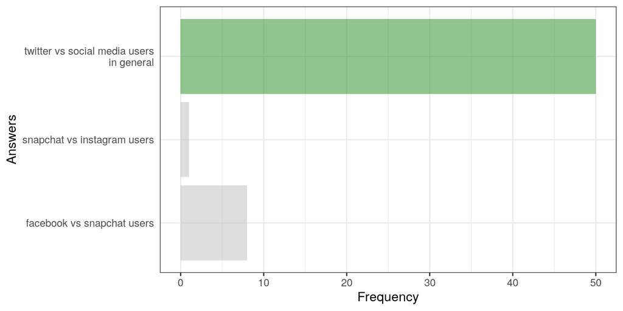

### What does linearity refer to?

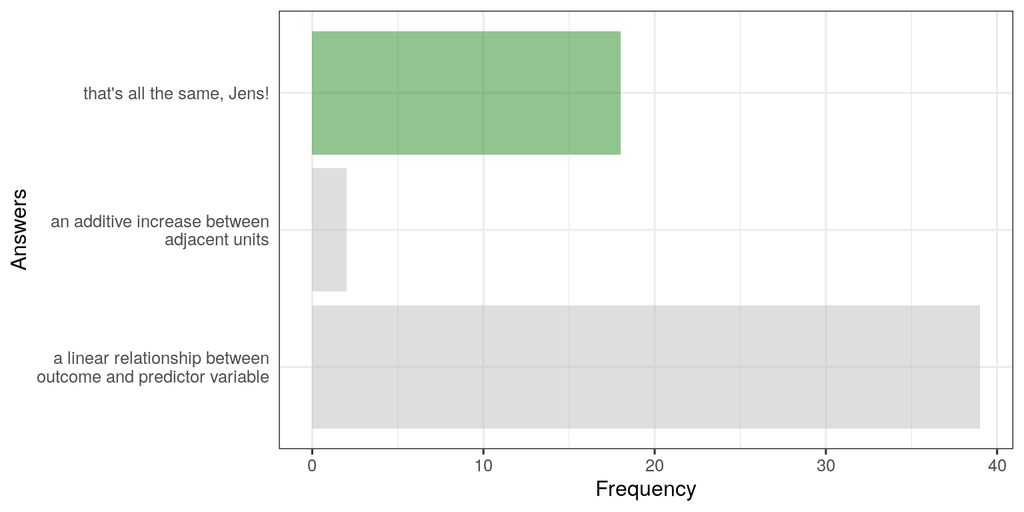

Ooops! Read all answers again. You got this :)

### Can linearity be violated for continuous predictors?

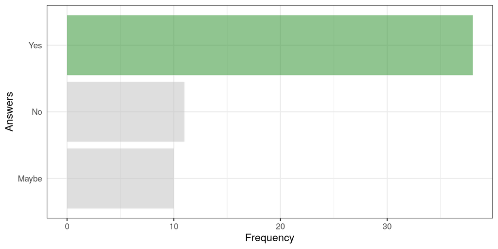

### Can linearity be violated for categorical predictors?

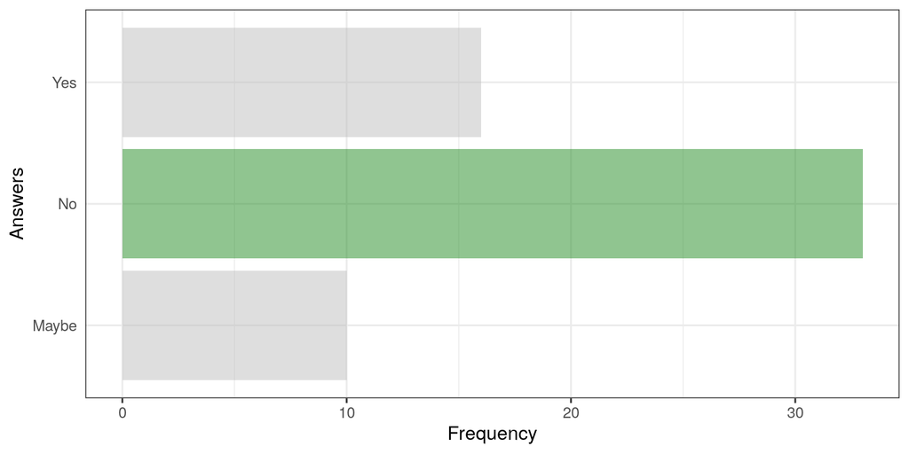

## Part 3: quiz evaluation

### I found this quiz useful to understand the main aspects of the lecture.

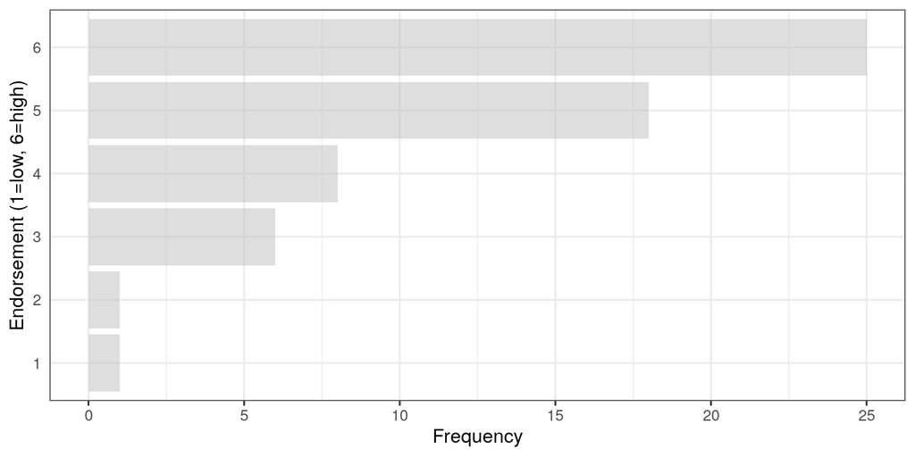

### I found the quiz too difficult.

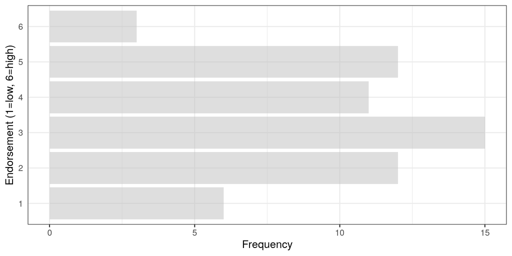

### There were too many questions.

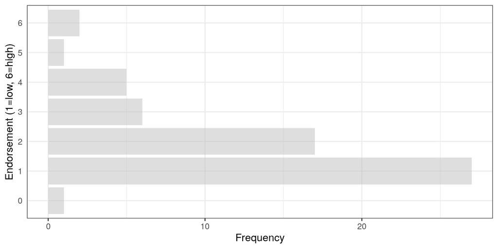

### I’d like more questions.

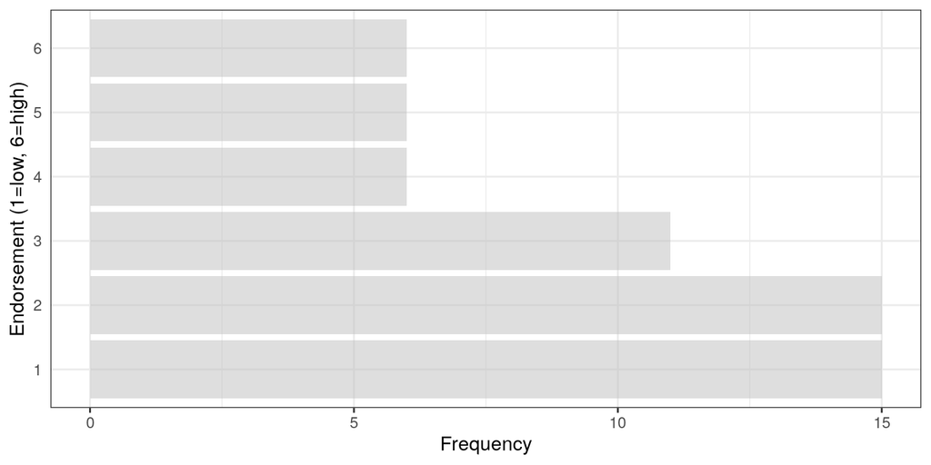

### I didn’t see how some questions related to the lecture.

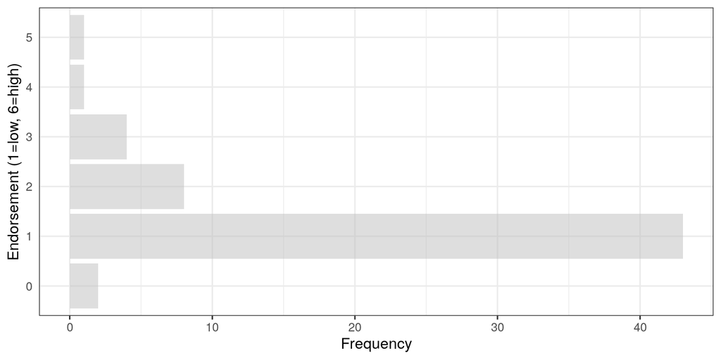

### Please keep using quizzes for lectures.

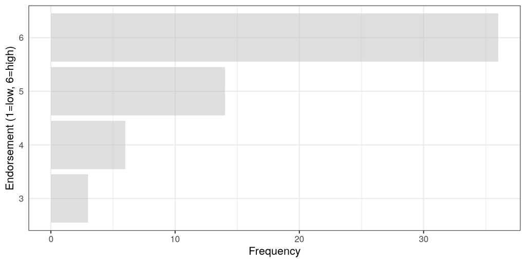

### I feel like this quiz increased my engagement.

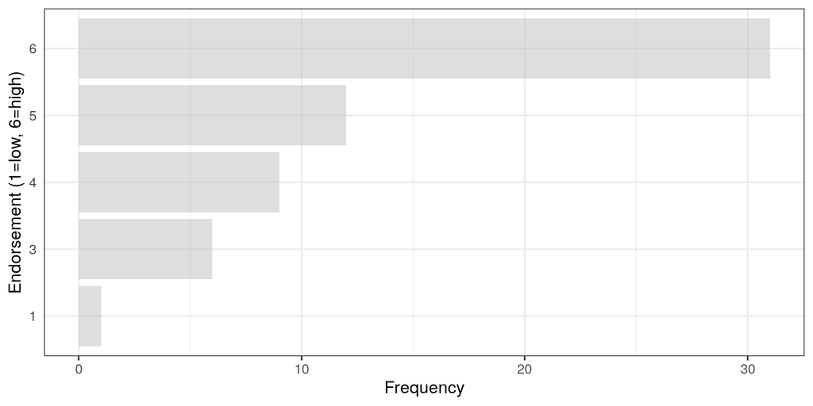

### Which statement applies to you (you can respond more than once)?

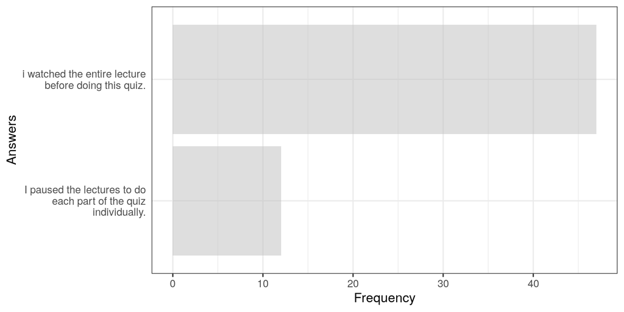

### Do you want to see the correct answers to this quiz?

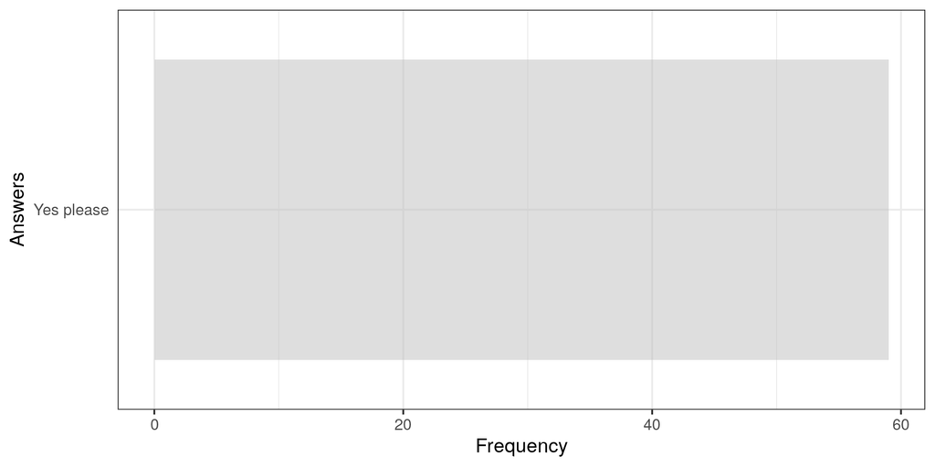